# Results pairwise testing

Renee Menezes

2022-03-11

### Introduction

Results of GEUVADIS and Leiden Longevity Study (LLS), for analyses involving pairwise testing, for each exon-SNP pair, per gene. Results are grouped per gene, to enable comparison with those of the spliceQTL test. Pairwise testing is performed per exon-SNP pair using a linear regression of the exon mRNA values on the SNP values (number of minor alleles).

The idea is to compare results across studies, using the pairwise testing, and check if reproducibility is the same as with the spliceQTL test.

```r
mydir.scripts <- "./scripts"
mydir.output <-  "./output"
mydir.data <- "./data"
mydir.output.perGene <- mydir.output

source(paste0(mydir.scripts, "/functions_wilcoxon_t_logistic_fdr.R"))
source(paste0(mydir.scripts, "/get_ov.R"))
```

### Read results pairwise testing

These results were produced using script `main_geuv_lls_lreg.R`, available in the `scripts` subfolder. We here read results per chromosome and check how many tests agree.

```r
th <- c(0.001, 0.005, 0.01)
for(chr in 1:22) # for(chr in 1:22)
{
#        cat("Analysing", chr, ":", as.character(Sys.time()), "\n")
        load(paste0(mydir.data, "/lregResults_Geuvadis_chr", chr, ".RData"))
        res.g <- myres
        load(paste0(mydir.data, "/lregResults_LLS_chr", chr, ".RData"))
        res.l <- myres
        if(length(res.g) >= length(res.l)) {
            ov <- names(res.g) %in% names(res.l)
            res.g <- res.g[ ov ]
            res.l <- res.l[ names(res.g) ]
            } else {
            ov <- names(res.l) %in% names(res.g)
            res.l <- res.l[ ov ]
            res.g <- res.g[ names(res.l) ]
        }
     pairs.cor <- sapply(names(res.g), getov.cor, res1 = res.g, res2 = res.l)
#     pairs.th <- sapply(names(res.g), getov.th, res1 = res.g, res2 = res.l, th = th)
     all.res <- sapply(names(res.g), getov2, res1 = res.g, res2 = res.l, th = th)
     mat.rownames <- data.frame(th = rep(th, 2), gid = rep(c("Geuv", "LLS"), each = length(th)))
     save(pairs.cor, all.res, mat.rownames,
          file = paste0(mydir.output, "/summary1_chr", chr, ".RData"))
}
```

### Explore results

We now count the number of genes with at least one pair selected, per dataset and threshold. To do so, we create a vector per dataset and threshold, with one entry per gene and a logical value indicating at least one selection. Then we tabulate the vector of the two datasets, per threshold. We also make a scatterplot of the number of selections made.

```r
th <- c(0.001, 0.005, 0.01)

chr <- 1

load(paste0(mydir.output, "/summary1_chr", chr, ".RData"))   # pairs.cor, all.res, mat.rownames
vcors <- pairs.cor
mat.rownames <- data.frame(th = rep(th, 2), gid = rep(c("Geuv", "LLS"), each = length(th)))
mat.allrows <- mat.rownames
vchr <- rep(chr, ncol(all.res))
mat.vsel <- all.res

for(chr in 2:22)
{
  load(paste0(mydir.output, "/summary1_chr", chr, ".RData"))   # pairs.cor, all.res, mat.rownames
  vcors <- c(vcors, pairs.cor)
  vchr <- c(vchr, rep(chr, ncol(all.res)))
  mat.vsel <- cbind(mat.vsel, all.res)
}
```

Per threshold, the cross-tabulation of genes with at least one exon-snp pair selected is:

```r
for(xth in th)
{
   myt <- table(mat.vsel[(mat.allrows$th == xth)&(mat.allrows$gid == "Geuv"), ] == 0,
                mat.vsel[(mat.allrows$th == xth)&(mat.allrows$gid == "LLS"), ] == 0)
   print(myt)
#   print(chisq.test(myt))
#   print(mcnemar.test(myt))
   myt <- 100*myt/sum(myt)
   print(chisq.test(myt))
   print(mcnemar.test(myt))

}
```

```
##
##         FALSE TRUE
##   FALSE  7865 2016
##   TRUE   3141 4358
##
##  Pearson's Chi-squared test with Yates' continuity correction
##
## data:  myt
## X-squared = 13.442, df = 1, p-value = 0.0002461
##
##
##  McNemar's Chi-squared test with continuity correction
##
## data:  myt
## McNemar's chi-squared = 1.0095, df = 1, p-value = 0.315
##
##
##         FALSE  TRUE
##   FALSE 10807  1714
##   TRUE   2330  2529
##
##  Pearson's Chi-squared test with Yates' continuity correction
##
## data:  myt
## X-squared = 14.049, df = 1, p-value = 0.0001782
##
##
##  McNemar's Chi-squared test with continuity correction
##
## data:  myt
## McNemar's chi-squared = 0.27821, df = 1, p-value = 0.5979
##
##
##         FALSE  TRUE
##   FALSE 12180  1477
##   TRUE   1903  1820
```

```
##
##  Pearson's Chi-squared test with Yates' continuity correction
##
## data:  myt
## X-squared = 13.491, df = 1, p-value = 0.0002397
##
##
##  McNemar's Chi-squared test with continuity correction
##
## data:  myt
## McNemar's chi-squared = 0.10827, df = 1, p-value = 0.7421
```

The scatterplots of the proportion selected, for each threshold, are displayed below. This is supplementary figure 9, with panels arranged horizontally rather than vertically.

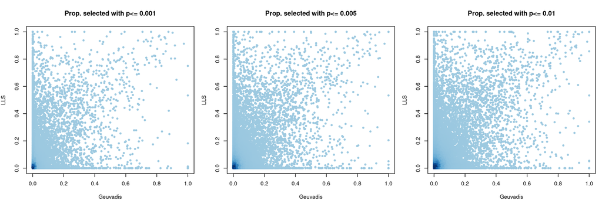

```r
par(mfrow = c(1, 3), mar = c(4, 4, 4, 1))
xth <- th[1]
dcols <- densCols(mat.vsel[(mat.allrows$th == xth)&(mat.allrows$gid == "Geuv"), ] ,
                  mat.vsel[(mat.allrows$th == xth)&(mat.allrows$gid == "LLS"), ])
plot(mat.vsel[(mat.allrows$th == xth)&(mat.allrows$gid == "Geuv"), ] ,
     mat.vsel[(mat.allrows$th == xth)&(mat.allrows$gid == "LLS"), ], pch = 20, col = dcols,
     xlab = "Geuvadis", ylab = "LLS", main =paste("Prop. selected with p<=", xth))

xth <- th[2]
dcols <- densCols(mat.vsel[(mat.allrows$th == xth)&(mat.allrows$gid == "Geuv"), ] ,
                  mat.vsel[(mat.allrows$th == xth)&(mat.allrows$gid == "LLS"), ])
plot(mat.vsel[(mat.allrows$th == xth)&(mat.allrows$gid == "Geuv"), ] ,
     mat.vsel[(mat.allrows$th == xth)&(mat.allrows$gid == "LLS"), ], pch = 20, col = dcols,
     xlab = "Geuvadis", ylab = "LLS", main =paste("Prop. selected with p<=", xth))

xth <- th[3]
dcols <- densCols(mat.vsel[(mat.allrows$th == xth)&(mat.allrows$gid == "Geuv"), ] ,
                  mat.vsel[(mat.allrows$th == xth)&(mat.allrows$gid == "LLS"), ])
plot(mat.vsel[(mat.allrows$th == xth)&(mat.allrows$gid == "Geuv"), ] ,
     mat.vsel[(mat.allrows$th == xth)&(mat.allrows$gid == "LLS"), ], pch = 20, col = dcols,
     xlab = "Geuvadis", ylab = "LLS", main =paste("Prop. selected with p<=", xth))
```

Of course, the above are threshold-dependent. We also computed correlations between `-log(p)` values for each gene, whenever the same exon-SNP pairs were available for both datasets. This is supplementary figure 8.

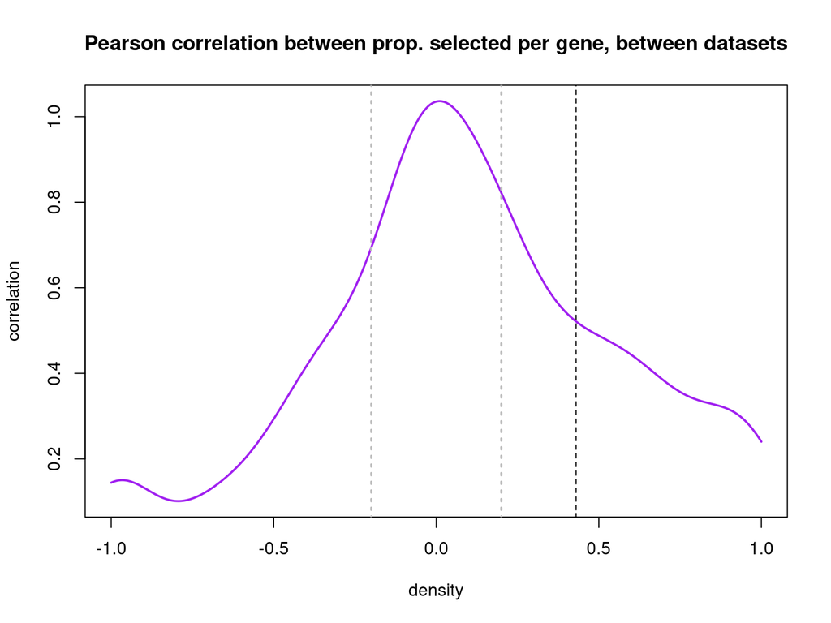

```r
vcors <- unlist(vcors)
plot(density(vcors[!is.na(vcors)], from = -1, to = 1),
     lty = "solid", lwd = 2, col = "purple", xlab = "density",
     ylab = "correlation", main = "Pearson correlation between prop. selected per gene, between datasets")
for(xl in c(-0.2, 0.2))
  segments(xl, 0, xl, 10, lty = "dotted", col = "gray", lwd = 2)
segments(0.43, 0, 0.43, 10, lty = "dashed", col = "black")
```

The summary of the correlations is:

```r
summary(vcors[!is.na(vcors)])
```

```
##     Min.  1st Qu.   Median     Mean  3rd Qu.     Max.
## -1.00000 -0.15792  0.07677  0.10359  0.41889  1.00000
```

```r
sum(vcors[!is.na(vcors)] < 0)/sum(!is.na(vcors))
```

```
## [1] 0.4176707
```

```r
sum(vcors[!is.na(vcors)] > 0.4308 )/sum(!is.na(vcors))
```

```
## [1] 0.2369478
```

```r
sum(abs(vcors[!is.na(vcors)]) <= 0.2)/sum(!is.na(vcors))
```

```
## [1] 0.3882195
```

```r
sum(vcors[!is.na(vcors)] <= -0.2 )/sum(!is.na(vcors))
```

```
## [1] 0.2208835
```